# FIFA 19 Exploration

## Preliminary Wrangling

> This dataset contains detailed attributes for every player registered in the latest edition of FIFA 19 database.

```python
# import all packages and set plots to be embedded inline
import numpy as np
import pandas as pd
import matplotlib.pyplot as plt
import seaborn as sb

%matplotlib inline
```

```python
# reading the data
df = pd.read_csv('../Fifa_19_dataset.csv')
# Setting max number of columns to display
pd.set_option("display.max_columns", 89)
```

```python
# A quick peek in the dataset
df.head()
```

|  | Unnamed: 0 | ID | Name | Age | Photo | Nationality | Flag | Overall | Potential | Club | Club Logo | Value | Wage | Special | Preferred Foot | International Reputation | Weak Foot | Skill Moves | Work Rate | Body Type | Real Face | Position | Jersey Number | Joined | Loaned From | Contract Valid Until | Height | Weight | LS | … |
| --- | --- | --- | --- | --- | --- | --- | --- | --- | --- | --- | --- | --- | --- | --- | --- | --- | --- | --- | --- | --- | --- | --- | --- | --- | --- | --- | --- | --- | --- | --- |
| 0 | 0 | 158023 | L. Messi | 31 | https://cdn.sofifa.org/players/4/19/158023.png | Argentina | https://cdn.sofifa.org/flags/52.png | 94 | 94 | FC Barcelona | https://cdn.sofifa.org/teams/2/light/241.png | €110.5M | €565K | 2202 | Left | 5.0 | 4.0 | 4.0 | Medium/ Medium | Messi | Yes | RF | 10.0 | Jul 1, 2004 | NaN | 2021 | 5'7 | 159lbs | 88+2 | … |
| 1 | 1 | 20801 | Cristiano Ronaldo | 33 | https://cdn.sofifa.org/players/4/19/20801.png | Portugal | https://cdn.sofifa.org/flags/38.png | 94 | 94 | Juventus | https://cdn.sofifa.org/teams/2/light/45.png | €77M | €405K | 2228 | Right | 5.0 | 4.0 | 5.0 | High/ Low | C. Ronaldo | Yes | ST | 7.0 | Jul 10, 2018 | NaN | 2022 | 6'2 | 183lbs | 91+3 | … |
| 2 | 2 | 190871 | Neymar Jr | 26 | https://cdn.sofifa.org/players/4/19/190871.png | Brazil | https://cdn.sofifa.org/flags/54.png | 92 | 93 | Paris Saint-Germain | https://cdn.sofifa.org/teams/2/light/73.png | €118.5M | €290K | 2143 | Right | 5.0 | 5.0 | 5.0 | High/ Medium | Neymar | Yes | LW | 10.0 | Aug 3, 2017 | NaN | 2022 | 5'9 | 150lbs | 84+3 | … |
| 3 | 3 | 193080 | De Gea | 27 | https://cdn.sofifa.org/players/4/19/193080.png | Spain | https://cdn.sofifa.org/flags/45.png | 91 | 93 | Manchester United | https://cdn.sofifa.org/teams/2/light/11.png | €72M | €260K | 1471 | Right | 4.0 | 3.0 | 1.0 | Medium/ Medium | Lean | Yes | GK | 1.0 | Jul 1, 2011 | NaN | 2020 | 6'4 | 168lbs | NaN | … |
| 4 | 4 | 192985 | K. De Bruyne | 27 | https://cdn.sofifa.org/players/4/19/192985.png | Belgium | https://cdn.sofifa.org/flags/7.png | 91 | 92 | Manchester City | https://cdn.sofifa.org/teams/2/light/10.png | €102M | €355K | 2281 | Right | 4.0 | 5.0 | 4.0 | High/ High | Normal | Yes | RCM | 7.0 | Aug 30, 2015 | NaN | 2023 | 5'11 | 154lbs | 82+3 | … |

```python
# Find the shape of the dataset
df.shape
```

```
(18207, 89)
```

```python
# check for duplicates
df[df.duplicated()]
```

|  | Unnamed: 0 | ID | Name | Age | Photo | Nationality | Flag | Overall | Potential | Club | Club Logo | Value | Wage | Special | Preferred Foot | International Reputation | Weak Foot | Skill Moves | Work Rate | Body Type | Real Face | Position | Jersey Number | Joined | Loaned From | Contract Valid Until | Height | Weight | LS | … |
| --- | --- | --- | --- | --- | --- | --- | --- | --- | --- | --- | --- | --- | --- | --- | --- | --- | --- | --- | --- | --- | --- | --- | --- | --- | --- | --- | --- | --- | --- | --- |

```python
# view all columns with their info
df.info();
```

```
<class 'pandas.core.frame.DataFrame'>
RangeIndex: 18207 entries, 0 to 18206
Data columns (total 89 columns):
 #   Column                    Non-Null Count  Dtype
---  ------                    --------------  -----
 0   Unnamed: 0                18207 non-null  int64
 1   ID                        18207 non-null  int64
 2   Name                      18207 non-null  object
 3   Age                       18207 non-null  int64
 4   Photo                     18207 non-null  object
 5   Nationality               18207 non-null  object
 6   Flag                      18207 non-null  object
 7   Overall                   18207 non-null  int64
 8   Potential                 18207 non-null  int64
 9   Club                      17966 non-null  object
```

[output cut: 81 more lines]

We can see that some columns have missing values while others have incorrect types, therefore data wrangling is a essential. It is suspicious that the **Unnamed: 0** column is the same as the index of the dataset, so we will make sure of that before dropping it.

```python
(pd.Series(df.index) - df['Unnamed: 0']).value_counts()
```

```
0    18207
dtype: int64
```

```python
# the index and the Unnamed: 0 column have exactly the same values, so we can safely drop it.
df.drop(['Unnamed: 0'], inplace = True, axis = 1)
```

We can also drop other columns that would not benifit us in the investigation.

```python
df.drop(['ID','Photo','Flag','Club Logo','Special', 'LS', 'ST', 'RS', 'LW', 'LF', 'CF', 'RF', 'RW','LAM', 'CAM', 'RAM', \
         'LM', 'LCM', 'CM', 'RCM', 'RM', 'LWB', 'LDM','CDM', 'RDM', 'RWB', 'LB', 'LCB', \
         'CB', 'RCB', 'RB'], inplace = True, axis = 1)
```

Now for the missing values, we can see than the number 18159 is repeated more than once, so we investigate those missing values

```python
print(df['Preferred Foot'].isnull().sum())
df[df['Preferred Foot'].isnull()]
```

```
48
```

|  | Name | Age | Nationality | Overall | Potential | Club | Value | Wage | Preferred Foot | International Reputation | Weak Foot | Skill Moves | Work Rate | Body Type | Real Face | Position | Jersey Number | Joined | Loaned From | Contract Valid Until | Height | Weight | Crossing | Finishing | HeadingAccuracy | ShortPassing | Volleys | Dribbling | Curve | … |
| --- | --- | --- | --- | --- | --- | --- | --- | --- | --- | --- | --- | --- | --- | --- | --- | --- | --- | --- | --- | --- | --- | --- | --- | --- | --- | --- | --- | --- | --- | --- |
| 13236 | J. McNulty | 33 | Scotland | 62 | 62 | Rochdale | €120K | €1K | NaN | NaN | NaN | NaN | NaN | NaN | NaN | NaN | NaN | NaN | NaN | NaN | NaN | NaN | NaN | NaN | NaN | NaN | NaN | NaN | NaN | … |
| 13237 | J. Barrera | 29 | Nicaragua | 62 | 62 | Boyacá Chicó FC | €300K | €1K | NaN | NaN | NaN | NaN | NaN | NaN | NaN | NaN | NaN | NaN | NaN | NaN | NaN | NaN | NaN | NaN | NaN | NaN | NaN | NaN | NaN | … |
| 13238 | J. Stead | 35 | England | 62 | 62 | Notts County | €140K | €3K | NaN | NaN | NaN | NaN | NaN | NaN | NaN | NaN | NaN | NaN | NaN | NaN | NaN | NaN | NaN | NaN | NaN | NaN | NaN | NaN | NaN | … |
| 13239 | A. Semprini | 20 | Italy | 62 | 72 | Brescia | €425K | €1K | NaN | NaN | NaN | NaN | NaN | NaN | NaN | NaN | NaN | NaN | NaN | NaN | NaN | NaN | NaN | NaN | NaN | NaN | NaN | NaN | NaN | … |
| 13240 | R. Bingham | 24 | England | 62 | 66 | Hamilton Academical FC | €400K | €1K | NaN | NaN | NaN | NaN | NaN | NaN | NaN | NaN | NaN | NaN | NaN | NaN | NaN | NaN | NaN | NaN | NaN | NaN | NaN | NaN | NaN | … |
| 13241 | K. Dankowski | 21 | Poland | 62 | 72 | Śląsk Wrocław | €425K | €1K | NaN | NaN | NaN | NaN | NaN | NaN | NaN | NaN | NaN | NaN | NaN | NaN | NaN | NaN | NaN | NaN | NaN | NaN | NaN | NaN | NaN | … |
| 13242 | I. Colman | 23 | Argentina | 62 | 70 | Club Atlético Aldosivi | €450K | €2K | NaN | NaN | NaN | NaN | NaN | NaN | NaN | NaN | NaN | NaN | NaN | NaN | NaN | NaN | NaN | NaN | NaN | NaN | NaN | NaN | NaN | … |
| 13243 | M. Feeney | 19 | England | 62 | 78 | Everton | €600K | €5K | NaN | NaN | NaN | NaN | NaN | NaN | NaN | NaN | NaN | NaN | NaN | NaN | NaN | NaN | NaN | NaN | NaN | NaN | NaN | NaN | NaN | … |
| 13244 | R. Minor | 30 | Denmark | 62 | 62 | Hobro IK | €230K | €2K | NaN | NaN | NaN | NaN | NaN | NaN | NaN | NaN | NaN | NaN | NaN | NaN | NaN | NaN | NaN | NaN | NaN | NaN | NaN | NaN | NaN | … |
| 13245 | Klauss | 21 | Brazil | 62 | 69 | HJK Helsinki | €425K | €1K | NaN | NaN | NaN | NaN | NaN | NaN | NaN | NaN | NaN | NaN | NaN | NaN | NaN | NaN | NaN | NaN | NaN | NaN | NaN | NaN | NaN | … |
| 13246 | I. Sissoko | 22 | France | 62 | 68 | AS Béziers | €425K | €2K | NaN | NaN | NaN | NaN | NaN | NaN | NaN | NaN | NaN | NaN | NaN | NaN | NaN | NaN | NaN | NaN | NaN | NaN | NaN | NaN | NaN | … |
| 13247 | F. Hart | 28 | Austria | 62 | 62 | SV Mattersburg | €240K | €3K | NaN | NaN | NaN | NaN | NaN | NaN | NaN | NaN | NaN | NaN | NaN | NaN | NaN | NaN | NaN | NaN | NaN | NaN | NaN | NaN | NaN | … |
| 13248 | L. McCullough | 24 | Northern Ireland | 62 | 69 | Tranmere Rovers | €375K | €2K | NaN | NaN | NaN | NaN | NaN | NaN | NaN | NaN | NaN | NaN | NaN | NaN | NaN | NaN | NaN | NaN | NaN | NaN | NaN | NaN | NaN | … |
| 13249 | Li Yunqiu | 27 | China PR | 62 | 62 | Shanghai Greenland Shenhua FC | €250K | €3K | NaN | NaN | NaN | NaN | NaN | NaN | NaN | NaN | NaN | NaN | NaN | NaN | NaN | NaN | NaN | NaN | NaN | NaN | NaN | NaN | NaN | … |
| 13250 | F. Garcia | 29 | Paraguay | 62 | 62 | Itagüí Leones FC | €300K | €1K | NaN | NaN | NaN | NaN | NaN | NaN | NaN | NaN | NaN | NaN | NaN | NaN | NaN | NaN | NaN | NaN | NaN | NaN | NaN | NaN | NaN | … |
| 13251 | R. Haemhouts | 34 | Belgium | 62 | 62 | NAC Breda | €150K | €2K | NaN | NaN | NaN | NaN | NaN | NaN | NaN | NaN | NaN | NaN | NaN | NaN | NaN | NaN | NaN | NaN | NaN | NaN | NaN | NaN | NaN | … |
| 13252 | E. Binaku | 22 | Albania | 62 | 70 | Malmö FF | €375K | €1K | NaN | NaN | NaN | NaN | NaN | NaN | NaN | NaN | NaN | NaN | NaN | NaN | NaN | NaN | NaN | NaN | NaN | NaN | NaN | NaN | NaN | … |
| 13253 | G. Miller | 31 | Scotland | 62 | 62 | Carlisle United | €200K | €2K | NaN | NaN | NaN | NaN | NaN | NaN | NaN | NaN | NaN | NaN | NaN | NaN | NaN | NaN | NaN | NaN | NaN | NaN | NaN | NaN | NaN | … |
| 13254 | A. Aidonis | 17 | Germany | 62 | 82 | VfB Stuttgart | €550K | €2K | NaN | NaN | NaN | NaN | NaN | NaN | NaN | NaN | NaN | NaN | NaN | NaN | NaN | NaN | NaN | NaN | NaN | NaN | NaN | NaN | NaN | … |
| 13255 | L. Sowah | 25 | Germany | 62 | 65 | Hamilton Academical FC | €325K | €1K | NaN | NaN | NaN | NaN | NaN | NaN | NaN | NaN | NaN | NaN | NaN | NaN | NaN | NaN | NaN | NaN | NaN | NaN | NaN | NaN | NaN | … |
| 13256 | R. Deacon | 26 | England | 62 | 62 | Dundee FC | €325K | €1K | NaN | NaN | NaN | NaN | NaN | NaN | NaN | NaN | NaN | NaN | NaN | NaN | NaN | NaN | NaN | NaN | NaN | NaN | NaN | NaN | NaN | … |
| 13257 | Jang Hyun Soo | 25 | Korea Republic | 62 | 65 | Suwon Samsung Bluewings | €375K | €2K | NaN | NaN | NaN | NaN | NaN | NaN | NaN | NaN | NaN | NaN | NaN | NaN | NaN | NaN | NaN | NaN | NaN | NaN | NaN | NaN | NaN | … |
| 13258 | A. Al Malki | 23 | Saudi Arabia | 62 | 67 | Al Wehda | €350K | €3K | NaN | NaN | NaN | NaN | NaN | NaN | NaN | NaN | NaN | NaN | NaN | NaN | NaN | NaN | NaN | NaN | NaN | NaN | NaN | NaN | NaN | … |
| 13259 | E. Guerrero | 27 | Chile | 62 | 65 | CD Palestino | €300K | €1K | NaN | NaN | NaN | NaN | NaN | NaN | NaN | NaN | NaN | NaN | NaN | NaN | NaN | NaN | NaN | NaN | NaN | NaN | NaN | NaN | NaN | … |
| 13260 | Hernáiz | 20 | Spain | 62 | 69 | Albacete BP | €425K | €1K | NaN | NaN | NaN | NaN | NaN | NaN | NaN | NaN | NaN | NaN | NaN | NaN | NaN | NaN | NaN | NaN | NaN | NaN | NaN | NaN | NaN | … |
| 13261 | H. Al Mansour | 25 | Saudi Arabia | 62 | 64 | Al Nassr | €300K | €5K | NaN | NaN | NaN | NaN | NaN | NaN | NaN | NaN | NaN | NaN | NaN | NaN | NaN | NaN | NaN | NaN | NaN | NaN | NaN | NaN | NaN | … |
| 13262 | H. Paul | 24 | Germany | 62 | 66 | TSV 1860 München | €325K | €1K | NaN | NaN | NaN | NaN | NaN | NaN | NaN | NaN | NaN | NaN | NaN | NaN | NaN | NaN | NaN | NaN | NaN | NaN | NaN | NaN | NaN | … |
| 13263 | S. Bauer | 25 | Austria | 62 | 66 | FC Admira Wacker Mödling | €325K | €2K | NaN | NaN | NaN | NaN | NaN | NaN | NaN | NaN | NaN | NaN | NaN | NaN | NaN | NaN | NaN | NaN | NaN | NaN | NaN | NaN | NaN | … |
| 13264 | M. Chergui | 29 | France | 62 | 62 | Grenoble Foot 38 | €300K | €1K | NaN | NaN | NaN | NaN | NaN | NaN | NaN | NaN | NaN | NaN | NaN | NaN | NaN | NaN | NaN | NaN | NaN | NaN | NaN | NaN | NaN | … |
| 13265 | D. Gardner | 28 | England | 62 | 62 | Oldham Athletic | €300K | €3K | NaN | NaN | NaN | NaN | NaN | NaN | NaN | NaN | NaN | NaN | NaN | NaN | NaN | NaN | NaN | NaN | NaN | NaN | NaN | NaN | NaN | … |
| 13266 | L. Bengtsson | 20 | Sweden | 62 | 73 | Hammarby IF | €525K | €1K | NaN | NaN | NaN | NaN | NaN | NaN | NaN | NaN | NaN | NaN | NaN | NaN | NaN | NaN | NaN | NaN | NaN | NaN | NaN | NaN | NaN | … |
| 13267 | F. Jaramillo | 22 | Colombia | 62 | 70 | Itagüí Leones FC | €450K | €1K | NaN | NaN | NaN | NaN | NaN | NaN | NaN | NaN | NaN | NaN | NaN | NaN | NaN | NaN | NaN | NaN | NaN | NaN | NaN | NaN | NaN | … |
| 13268 | L. Garguła | 37 | Poland | 62 | 62 | Miedź Legnica | €100K | €1K | NaN | NaN | NaN | NaN | NaN | NaN | NaN | NaN | NaN | NaN | NaN | NaN | NaN | NaN | NaN | NaN | NaN | NaN | NaN | NaN | NaN | … |
| 13269 | S. Rivera | 26 | Colombia | 62 | 64 | Jaguares de Córdoba | €375K | €1K | NaN | NaN | NaN | NaN | NaN | NaN | NaN | NaN | NaN | NaN | NaN | NaN | NaN | NaN | NaN | NaN | NaN | NaN | NaN | NaN | NaN | … |
| 13270 | Vinicius | 19 | Brazil | 62 | 77 | Bologna | €525K | €1K | NaN | NaN | NaN | NaN | NaN | NaN | NaN | NaN | NaN | NaN | NaN | NaN | NaN | NaN | NaN | NaN | NaN | NaN | NaN | NaN | NaN | … |
| 13271 | F. Sepúlveda | 26 | Chile | 62 | 63 | CD Antofagasta | €290K | €1K | NaN | NaN | NaN | NaN | NaN | NaN | NaN | NaN | NaN | NaN | NaN | NaN | NaN | NaN | NaN | NaN | NaN | NaN | NaN | NaN | NaN | … |
| 13272 | L. Spence | 22 | Scotland | 62 | 70 | Dundee FC | €450K | €1K | NaN | NaN | NaN | NaN | NaN | NaN | NaN | NaN | NaN | NaN | NaN | NaN | NaN | NaN | NaN | NaN | NaN | NaN | NaN | NaN | NaN | … |
| 13273 | B. Lepistu | 25 | Estonia | 62 | 67 | Kristiansund BK | €400K | €1K | NaN | NaN | NaN | NaN | NaN | NaN | NaN | NaN | NaN | NaN | NaN | NaN | NaN | NaN | NaN | NaN | NaN | NaN | NaN | NaN | NaN | … |
| 13274 | A. Abruscia | 27 | Italy | 62 | 62 | TSV 1860 München | €325K | €2K | NaN | NaN | NaN | NaN | NaN | NaN | NaN | NaN | NaN | NaN | NaN | NaN | NaN | NaN | NaN | NaN | NaN | NaN | NaN | NaN | NaN | … |
| 13275 | E. González | 23 | Venezuela | 62 | 70 | Boyacá Chicó FC | €375K | €1K | NaN | NaN | NaN | NaN | NaN | NaN | NaN | NaN | NaN | NaN | NaN | NaN | NaN | NaN | NaN | NaN | NaN | NaN | NaN | NaN | NaN | … |
| 13276 | M. Al Amri | 26 | Saudi Arabia | 62 | 63 | Al Raed | €290K | €3K | NaN | NaN | NaN | NaN | NaN | NaN | NaN | NaN | NaN | NaN | NaN | NaN | NaN | NaN | NaN | NaN | NaN | NaN | NaN | NaN | NaN | … |
| 13277 | J. Rebolledo | 26 | Chile | 62 | 62 | Deportes Iquique | €325K | €1K | NaN | NaN | NaN | NaN | NaN | NaN | NaN | NaN | NaN | NaN | NaN | NaN | NaN | NaN | NaN | NaN | NaN | NaN | NaN | NaN | NaN | … |
| 13278 | C. Mamengi | 17 | Netherlands | 62 | 79 | FC Utrecht | €550K | €1K | NaN | NaN | NaN | NaN | NaN | NaN | NaN | NaN | NaN | NaN | NaN | NaN | NaN | NaN | NaN | NaN | NaN | NaN | NaN | NaN | NaN | … |
| 13279 | P. Mazzocchi | 22 | Italy | 62 | 69 | Perugia | €350K | €1K | NaN | NaN | NaN | NaN | NaN | NaN | NaN | NaN | NaN | NaN | NaN | NaN | NaN | NaN | NaN | NaN | NaN | NaN | NaN | NaN | NaN | … |
| 13280 | Y. Ammour | 19 | France | 62 | 77 | Montpellier HSC | €650K | €2K | NaN | NaN | NaN | NaN | NaN | NaN | NaN | NaN | NaN | NaN | NaN | NaN | NaN | NaN | NaN | NaN | NaN | NaN | NaN | NaN | NaN | … |
| 13281 | Jwa Joon Hyeop | 27 | Korea Republic | 62 | 62 | Gyeongnam FC | €300K | €1K | NaN | NaN | NaN | NaN | NaN | NaN | NaN | NaN | NaN | NaN | NaN | NaN | NaN | NaN | NaN | NaN | NaN | NaN | NaN | NaN | NaN | … |
| 13282 | O. Marrufo | 25 | Mexico | 62 | 65 | Tiburones Rojos de Veracruz | €375K | €2K | NaN | NaN | NaN | NaN | NaN | NaN | NaN | NaN | NaN | NaN | NaN | NaN | NaN | NaN | NaN | NaN | NaN | NaN | NaN | NaN | NaN | … |
| 13283 | Han Pengfei | 25 | China PR | 62 | 66 | Guizhou Hengfeng FC | €325K | €2K | NaN | NaN | NaN | NaN | NaN | NaN | NaN | NaN | NaN | NaN | NaN | NaN | NaN | NaN | NaN | NaN | NaN | NaN | NaN | NaN | NaN | … |

We can see that there are 48 rows with so many missing features, since they are few compared to the dataset, we can safely drop them.

```python
df.drop(df[df['Preferred Foot'].isnull()].index,inplace=True)
```

Now we make sure the correct data format is given for each column.

```python
# convert joined to datetime
df['Joined'] = pd.to_datetime(df['Joined'])
```

Next we need to create a function to convert price from string to number depending on the string unit (eg. Millions, Thousands, ...)

First, we make sure that all prices have the same structures.

```python
all_prices = pd.concat([df['Value'],df['Wage'],df['Release Clause']])
all_prices.str[0:1].value_counts()
```

```
€    52961
dtype: int64
```

```python
all_prices.str[-1].value_counts()
```

```
K    36471
M    15997
0      493
dtype: int64
```

We can see that they all have the same structure, now we create the function.

```python
# create function to convert price from string to number depending on the string unit (eg. Millions, Thousands, ...)
def convertPrice(price):
    # handle nan
    if(price != price):
        return 0

    int_price = 0;
    # check last digit in price
    if(price[-1] == 'K'):
        int_price = int(float(price[1:-1])*1000)
    elif(price[-1] == 'M'):
        int_price = int(float(price[1:-1])*1000000)
    else:
        int_price = int(price[1:])
    return int_price
```

```python
# convert prices
df['Value'] = df['Value'].apply(lambda x:convertPrice(x));
df['Wage'] = df['Wage'].apply(lambda x:convertPrice(x));
df['Release Clause'] = df['Release Clause'].apply(lambda x:convertPrice(x));
```

```python
# Check weight values format.
df['Weight'].str[-3:].value_counts()
```

```
lbs    18159
Name: Weight, dtype: int64
```

```python
# convert weights column to numeric values
df['Weight'] = df['Weight'].apply(lambda x: 0 if x!=x else int(x[:-3]))
```

```python
# create function to convert heights column to centimeters
def feetToCm(height):
    # handle nan
    if(height!=height):
        return 0

    # multiply feet by 30.48 and inches by 2.54
    return int(height.split("\'")[0])*30.48 + int(height.split("\'")[1])*2.54
```

```python
# Convert height from feet and inches to centimeters
df['Height'] = df['Height'].apply(lambda x: feetToCm(x))
```

```python
df.shape
```

```
(18159, 57)
```

### What is the structure of your dataset?

> The dataset initially contained 18207 records with 89 features, after some data wrangling, only 57 features are selected and 48 entries were dropped giving a 18159 by 57 dataframe.

### What is/are the main feature(s) of interest in your dataset?

> The main features on interest are the player value, wage and overall.

### What features in the dataset do you think will help support your investigation into your feature(s) of interest?

> The player's age, potential, club, skill moves, and other qualities like dribbiling rating, balance rating, shot power rating, and so on.

## Univariate Exploration

> In this section, we investigate the distributions of individual variables.

First we explore interesting numeric features in the dataset using histograms

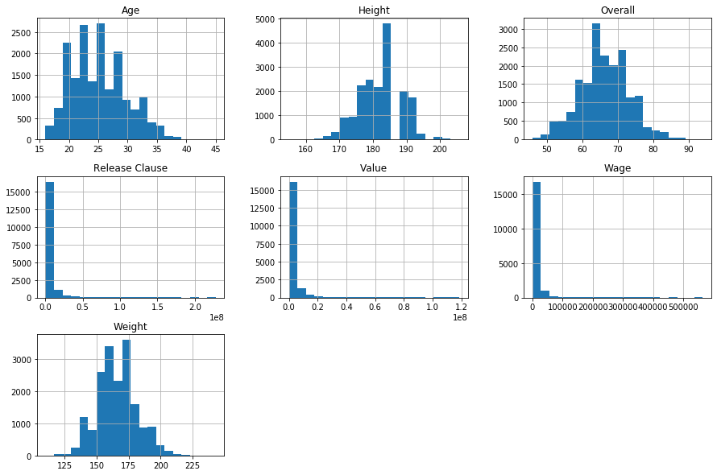

```python
fig = plt.figure(figsize = (15,10))
ax = fig.gca()
ax.ticklabel_format(useOffset=False, style='plain')
df[['Age','Overall','Value','Wage','Release Clause','Height', 'Weight']].hist(ax=ax, bins = 20);
plt.ticklabel_format(useOffset=False, style='plain')
```

We can see that the players age, overall rating, weight and height almost follow a normal distribution curve while the release clause, value and wage columns show a right skewed graph. This is expected because only top players have high value, salary, and release clause. On the other hand, most players are in their 20's and have an overall rating between 65 and 75. Furthermore, the majority of the players in the dataset have an approximate of 185cm height and a 155lbs - 175lbs weight.

Since few players have high overall rating and few players have a high value, we can expect to find a releation between them.

Next, we explore the categorical variables.

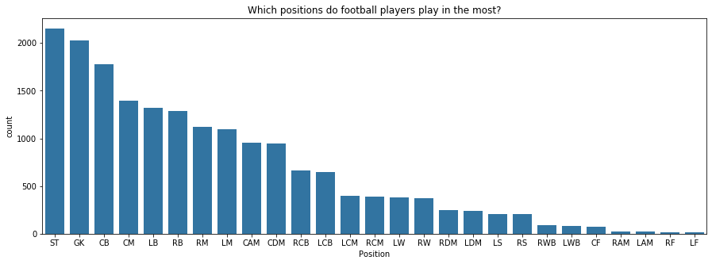

```python
plt.figure(figsize = (15,5))
base_color = sb.color_palette()[0]
position_ordered = df['Position'].value_counts().index
sb.countplot(data=df, x='Position',color = base_color, order = position_ordered);
plt.title('Which positions do football players play in the most?');
```

We can see that the striker position (ST) has the most players followed by the goal keeper position (GK) while the least positions are the RF and LF, this may be because most team formations don't include the RF or LF positions, instead they prefere to have RW and LW or any other formation.

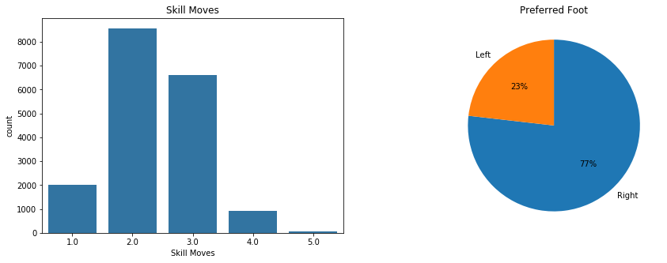

```python
plt.figure(figsize=(15,5))

# Skill Moves
plt.subplot(1,2,1)
sb.countplot(data = df, x='Skill Moves',color = base_color);
plt.title("Skill Moves");


# Preferred Foot
plt.subplot(1,2,2)
# sb.countplot(data = df, x='Preferred Foot',color = base_color,order = df['Preferred Foot'].value_counts().index);
plt.pie(df['Preferred Foot'].value_counts(),startangle = 90, counterclock = False, labels = ['Right','Left'], \
        autopct='%1.0f%%');
plt.title('Preferred Foot');
```

We can see that there are more than 3 times right foot players than left foot ones. We can also see that the majority of the players have skill moves rating of 2 out of 5, while those with the maximum skill moves rating (5) are the least, which can be a reason to increase their value or overall rating.

We can also investigate which clubs have top class players by selecting the top 100 overall players and checking which clubs they play for.

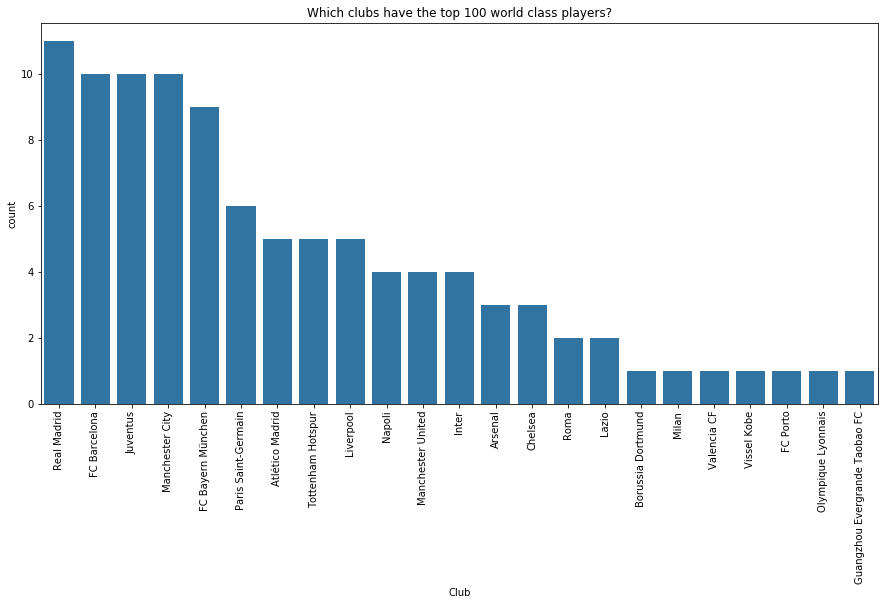

```python
plt.figure(figsize=(15,7))
order = df.nlargest(100, 'Overall').Club.value_counts().index
sb.countplot(data = df.nlargest(100, 'Overall'), x = 'Club', order=order, color=base_color);
plt.xticks(rotation=90);
plt.title('Which clubs have the top 100 world class players?');
```

Real Madrid comes first with the highest number of top class players, which is 11 players, followed by Juventus, FC Barcelona, and Manchester City, who all have 10 top class players.

## Bivariate Exploration

> In this section, we will investigate the relationships between pairs of variables in our data.

First, we explore the relationship between the **Potential** and **Release Clause** columns, the **Overall** and **Wage** Columns, and the **Height** and **Value** columns.

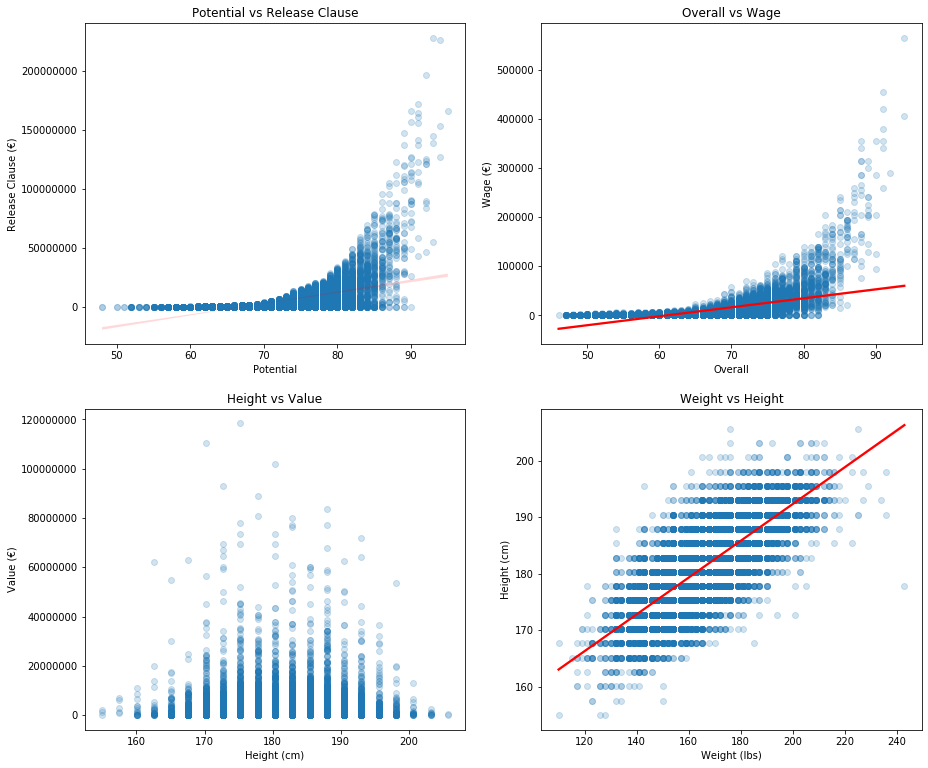

```python
plt.figure(figsize=(15,13))

# Potential vs Release Clause
plt.subplot(2,2,1)
sb.regplot(data = df, x='Potential',y='Release Clause',scatter_kws = {'alpha':1/5},line_kws={'color': 'red'})
plt.title("Potential vs Release Clause");
plt.ticklabel_format(useOffset=False, style='plain')
plt.xlabel('Potential')
plt.ylabel('Release Clause (€)')


# Overall vs Wage
plt.subplot(2,2,2)
sb.regplot(data = df, x='Overall',y='Wage',scatter_kws = {'alpha':1/5},line_kws={'color': 'red'})
plt.title("Overall vs Wage");
plt.ticklabel_format(useOffset=False, style='plain')
plt.xlabel('Overall')
plt.ylabel('Wage (€)')

# Height vs Value
plt.subplot(2,2,3)
sb.regplot(data = df, x='Height',y='Value',fit_reg=False,scatter_kws = {'alpha':1/5},line_kws={'color': 'red'})
plt.title("Height vs Value");
plt.ticklabel_format(useOffset=False, style='plain')
plt.xlabel('Height (cm)')
plt.ylabel('Value (€)');

# Weight vs Height
plt.subplot(2,2,4)
sb.regplot(data = df, x='Weight',y='Height',scatter_kws = {'alpha':1/5},line_kws={'color': 'red'})
plt.title("Weight vs Height");
plt.ticklabel_format(useOffset=False, style='plain')
plt.xlabel('Weight (lbs)')
plt.ylabel('Height (cm)');
```

We can see that there is an exponential relationship between the Potential and Release Clause column indicating that the more potential a player has, the harder it is for his club to let him go, thus increasing his release clause exponentially.

Furthermore, the Overall vs Wage plot also shows an exponential relationship which is expected because better players are supposed to have higher salary. It is also clear that most players have an income below €150,000 and only few of them receive higher wage since only few of them have high overall rating.

For the Height vs Value graph, a normal distribution curve is seen, showing that players with height between 170 and 185 cms approximately tend to have higher value. This may be due to the balance between the player height and stability, since the taller the player is, the less stable he will be, and the shorter the player is, the lower his jumping or heading might be.

Finally, the Weight vs Height graph shows a linear relationship indicating that as the player's height increases, his weight also increases, which is expected.

Next, we investigate if there is a relationship between the player's preffered foot and his overall rating and value.

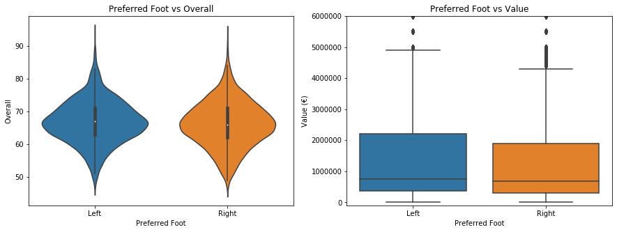

```python
plt.figure(figsize=(15,5))

plt.subplot(1,2,1)
sb.violinplot(data = df, x='Preferred Foot', y='Overall');
plt.title("Preferred Foot vs Overall");

plt.subplot(1,2,2)
sb.boxplot(data = df, x='Preferred Foot', y='Value');
plt.title("Preferred Foot vs Value");
plt.ylabel('Value (€)')
plt.ylim([-100000,6000000]);
```

After removing outliers, it can be seen that left foot players on average have higher value than right foot players, on the other hand, both left and right foot player show almost the same overall rating distribution.

Next, we explore which positions have highest salaries.

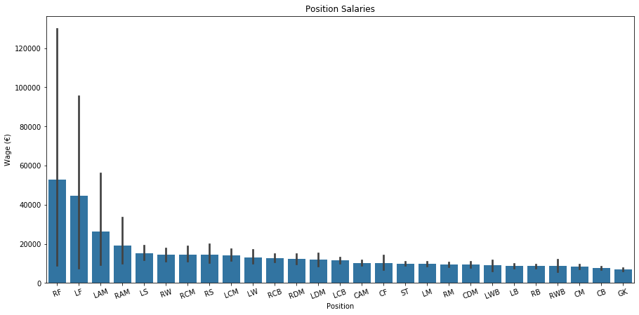

```python
plt.figure(figsize=(15,7))
order = df.groupby('Position')['Wage'].mean().sort_values(ascending=False)
sb.barplot(data = df, x='Position', y='Wage', color = base_color, order=order.index);
plt.xticks(rotation = 20)
plt.ylabel('Wage (€)');
plt.title('Position Salaries');
```

It can be seen than although the RF, LF, LAM, RAM positions have the highest wages, they have the highest errors or standard deviation, this is because we saw in our univariate exploration that they have the least number of players.

We can also investigate which clubs pay the highest salaries.

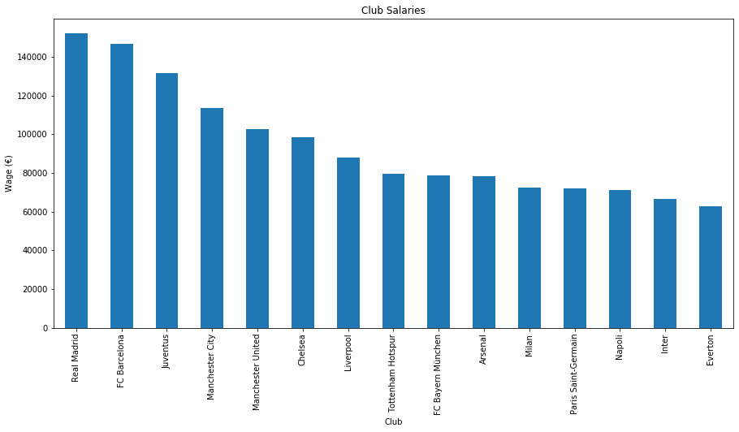

```python
plt.figure(figsize=(15, 7))
df.groupby(['Club'])['Wage'].mean().sort_values(ascending=False)[:15].plot(kind='bar');
plt.ylabel('Wage (€)');
plt.xticks(rotation=90);
plt.title('Club Salaries');
```

As expected, we can see that Real Madrid, which we saw before that it has the highest number of top class players, pays the highest salaries, followed by FC Barcelona, then Juventus, and Manchester City. This relationship was also seen in the **Wage** vs **Overall** graph.

Next, we explore how the skill moves vary with age and how it affects the overall rating of the player.

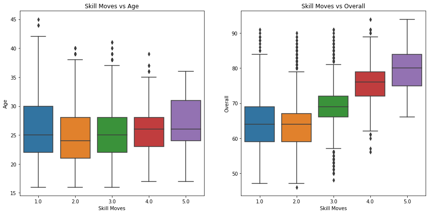

```python
plt.figure(figsize=(15,7))

plt.subplot(1,2,1)
sb.boxplot(data= df, x='Skill Moves', y='Age');
plt.title('Skill Moves vs Age')

plt.subplot(1,2,2)
sb.boxplot(data= df, x='Skill Moves', y='Overall');
plt.title('Skill Moves vs Overall');
```

We can see that there is a slight difference between the skill moves categories when they are compared to the age variable, on the other hand, higher skill moves will result in a higher overall rating, this can be seen since the 5 skill moves category showes the highest overall rating, followed by the 4 skill moves category, and so on.

Finally we explore how the skill moves are distributed between left and right foot players.

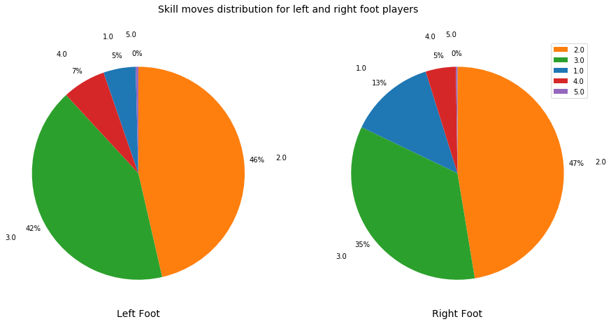

```python
plt.figure(figsize=(15,7))
fig = plt.gcf()
fig.suptitle("Skill moves distribution for left and right foot players", fontsize=14)

# define colors to map the same skill moves category to the same color
colors = {
    '1.0': 'C0',
    '2.0': 'C1',
    '3.0': 'C2',
    '4.0': 'C3',
    '5.0': 'C4'
}
# left skills
left_skills = df[df['Preferred Foot'] == 'Left'].groupby('Skill Moves')['Preferred Foot'] \
.count().sort_values(ascending=False);

# right skills
right_skills = df[df['Preferred Foot'] == 'Right'].groupby('Skill Moves')['Preferred Foot'] \
.count().sort_values(ascending=False)

plt.subplot(1,2,1)
left_skills.plot(kind = 'pie',startangle = 90, counterclock = False, autopct='%1.0f%%', pctdistance=1.12, \
                 labeldistance=1.3, colors=[colors[str(key)] for key in list(left_skills.index)]);
plt.ylabel('');
plt.xlabel('Left Foot',fontsize=14);


plt.subplot(1,2,2)
right_skills.plot(kind = 'pie',startangle = 90, counterclock = False, autopct='%1.0f%%', pctdistance=1.12, \
                  labeldistance=1.3, colors=[colors[str(key)] for key in list(right_skills.index)]);
plt.ylabel('');
plt.xlabel('Right Foot',fontsize=14);
plt.legend(('2.0','3.0','1.0','4.0','5.0'));
```

We can see that the ratio of level 2 and level 5 skill moves players is almost the same in the right and left foot players. However, it is clearly seen that left foot players are more in the 3 and 4 skill moves level than those in the right foot players. This can be an indicator that left foot players are generally more skilled than right foot ones.

## Multivariate Exploration

> In this section, we will create plots of three or more variables to investigate our data even further.

We can first find if the height and weight affects the balance of the player.

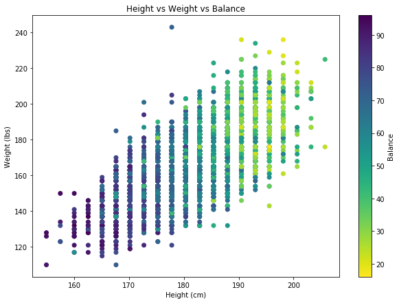

```python
plt.figure(figsize=(10,7))
plt.scatter(data=df, x = 'Height',y='Weight',c='Balance',cmap='viridis_r');
plt.colorbar(label = 'Balance')
plt.xlabel('Height (cm)')
plt.ylabel('Weight (lbs)');
plt.title('Height vs Weight vs Balance');
```

We observe that players with high balance tend to be short and light, while tall and heavy players tend to have less balance.

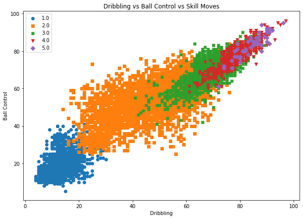

```python
plt.figure(figsize=(10,7))
cat_markers = [[1.0, 'o'],
               [2.0, 's'],
               [3.0, 'X'],
               [4.0, 'v'],
               [5.0, 'D'],]

for cat, marker in cat_markers:
    df_cat = df[df['Skill Moves'] == cat]
    plt.scatter(data = df_cat, x = 'Dribbling', y = 'BallControl', marker = marker)
plt.legend(['1.0','2.0','3.0','4.0','5.0']);
plt.xlabel('Dribbling')
plt.ylabel('Ball Control');
plt.title('Dribbling vs Ball Control vs Skill Moves');
```

We can see that there is a linear relationship between the dribbling and the ball control skills, as the player ball control skills increase, so does his dribbling skills. Moreover, we can see that players with low dribbling and ball control have lower skill moves, and those with high dribbling and ball control skills have high skill moves.

Next we investigate how the finishing and positioning relate to one another and to the player position, skill moves and international reputation. For simplification, we will limit the position to attack, defence, midfield, and goal keeper.

```python
def getPosition(position):
    if position in ['CAM', 'CDM','RM', 'LAM', 'LM','RDM','CM','RAM','RCM', 'LCM', 'LDM']:
        return 'Midfield'
    if position in ['LF', 'RS','RF', 'ST','LS','RW','CF','LW']:
        return 'Attack'
    if position in ['RWB', 'LWB','RCB', 'CB', 'LCB','LB','RB']:
        return 'Defense'
    if position == 'GK':
        return 'Goal Keeper'
```

```python
df['Role'] = df['Position'].apply(lambda x: getPosition(x))
```

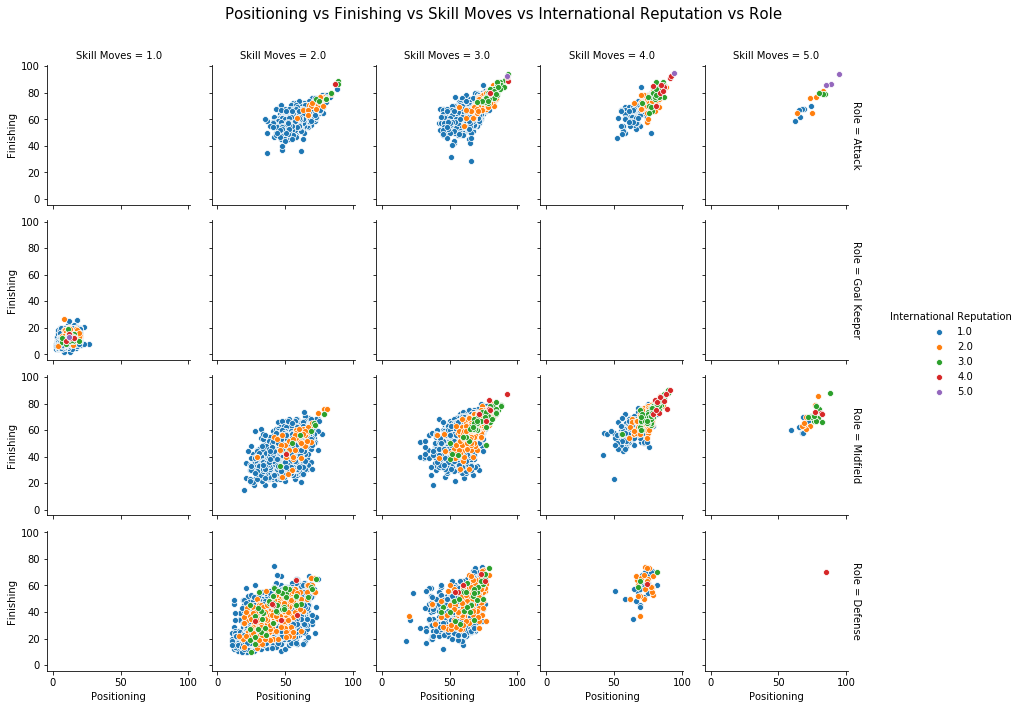

```python
g = sb.FacetGrid(data = df, col = 'Skill Moves', row = 'Role', hue='International Reputation', height = 2.5,
                margin_titles = True)
g.map(sb.scatterplot, 'Positioning', 'Finishing');
g.add_legend();
plt.subplots_adjust(top=0.9)
g.fig.suptitle('Positioning vs Finishing vs Skill Moves vs International Reputation vs Role',fontsize=15);
```

As we can see, there is generally a linear relationship between the player positioning and his finishing skills, the better a player can position himself, the more chances he can get to score goals.

It can also be seen that this linear relationship increases as the skill moves category increases, this is can be seen as the points come closer together. This event also occures as the player role changes, so for the defence role, the linear relationship is weak, then it is stronger in the midfield role, and is strongest in the attacking role.

Finally, we can see that the international reputation increases with the increase in skill category, as seen by reduction in the blue color, and with the increase in positioning and finishing.